# Online News Popularity

## First imports

### Importing modules

### Importing the dataset

## Data visualization and preprocessing

### Naive introductory overview of the dataset

### Formating the dataset

#### Dataset's description

#### Dataset's columns

#### Dataset's missing and misc. values

#### Dataset's outliers

### Transforming the dataset

#### Generic methods for vizualization and transformation

#### Examining the target *shares*

#### Transforming the feature *n_tokens_title*

#### Transforming the feature *n_tokens_content*

#### Transforming the feature *n_non_stop_words*

#### Transforming the feature *num_hrefs*

#### Transforming the feature *num_self_hrefs*

#### Transforming the feature *num_imgs*

#### Transforming the feature *num_videos*

#### Transforming the features *rate_positive_words* and *rate_negative_words*

#### Transforming the features *keywords*

#### Transforming the features *self_reference*

#### Transforming the features *data_channel*

#### Transforming the features *weekday* and *is_weekend*

#### Transforming the features *LDA*

#### Transforming the features *global*

#### Transforming the features *title*

#### Transforming the features *polarity*

### Regression models

### Flask regression

# First imports

## Importing modules

```python
import matplotlib.pyplot as plt # for plotting the dataset
import seaborn as sns # heatmap
import pandas as pd # import and transform the dataset
import numpy as np # calculations
```

## Importing the dataset

```python
data = pd.read_csv("OnlineNewsPopularity.csv")
```

# Data visualization and preprocessing

## Naive introductory overview of the dataset

```python
data.shape
```

```
(39644, 61)
```

```python
data.head(5)
```

|  | url | timedelta | n_tokens_title | n_tokens_content | n_unique_tokens | n_non_stop_words | n_non_stop_unique_tokens | num_hrefs | num_self_hrefs | num_imgs | ... | min_positive_polarity | max_positive_polarity | avg_negative_polarity | min_negative_polarity | max_negative_polarity | title_subjectivity | title_sentiment_polarity | abs_title_subjectivity | abs_title_sentiment_polarity | shares |
| --- | --- | --- | --- | --- | --- | --- | --- | --- | --- | --- | --- | --- | --- | --- | --- | --- | --- | --- | --- | --- | --- |
| 0 | http://mashable.com/2013/01/07/amazon-instant-... | 731.0 | 12.0 | 219.0 | 0.663594 | 1.0 | 0.815385 | 4.0 | 2.0 | 1.0 | ... | 0.100000 | 0.7 | -0.350000 | -0.600 | -0.200000 | 0.500000 | -0.187500 | 0.000000 | 0.187500 | 593 |
| 1 | http://mashable.com/2013/01/07/ap-samsung-spon... | 731.0 | 9.0 | 255.0 | 0.604743 | 1.0 | 0.791946 | 3.0 | 1.0 | 1.0 | ... | 0.033333 | 0.7 | -0.118750 | -0.125 | -0.100000 | 0.000000 | 0.000000 | 0.500000 | 0.000000 | 711 |
| 2 | http://mashable.com/2013/01/07/apple-40-billio... | 731.0 | 9.0 | 211.0 | 0.575130 | 1.0 | 0.663866 | 3.0 | 1.0 | 1.0 | ... | 0.100000 | 1.0 | -0.466667 | -0.800 | -0.133333 | 0.000000 | 0.000000 | 0.500000 | 0.000000 | 1500 |
| 3 | http://mashable.com/2013/01/07/astronaut-notre... | 731.0 | 9.0 | 531.0 | 0.503788 | 1.0 | 0.665635 | 9.0 | 0.0 | 1.0 | ... | 0.136364 | 0.8 | -0.369697 | -0.600 | -0.166667 | 0.000000 | 0.000000 | 0.500000 | 0.000000 | 1200 |
| 4 | http://mashable.com/2013/01/07/att-u-verse-apps/ | 731.0 | 13.0 | 1072.0 | 0.415646 | 1.0 | 0.540890 | 19.0 | 19.0 | 20.0 | ... | 0.033333 | 1.0 | -0.220192 | -0.500 | -0.050000 | 0.454545 | 0.136364 | 0.045455 | 0.136364 | 505 |

5 rows × 61 columns

## Formating the dataset

### Dataset's description

The dataset's description specifically considers the first two features *url* and *timedelta* as non-predictive. Let us remove them from the main dataset. Nevertheless, we'll store them elsewhere for a potential alternative model to compare.

```python
data_url = data['url']
data_timedelta = data[' timedelta']
data = data.drop(['url', ' timedelta'], 1)
```

### Dataset's columns

```python
data.columns
```

```
Index([' n_tokens_title', ' n_tokens_content', ' n_unique_tokens',
       ' n_non_stop_words', ' n_non_stop_unique_tokens', ' num_hrefs',
       ' num_self_hrefs', ' num_imgs', ' num_videos', ' average_token_length',
       ' num_keywords', ' data_channel_is_lifestyle',
       ' data_channel_is_entertainment', ' data_channel_is_bus',
       ' data_channel_is_socmed', ' data_channel_is_tech',
       ' data_channel_is_world', ' kw_min_min', ' kw_max_min', ' kw_avg_min',
       ' kw_min_max', ' kw_max_max', ' kw_avg_max', ' kw_min_avg',
       ' kw_max_avg', ' kw_avg_avg', ' self_reference_min_shares',
       ' self_reference_max_shares', ' self_reference_avg_sharess',
       ' weekday_is_monday', ' weekday_is_tuesday', ' weekday_is_wednesday',
       ' weekday_is_thursday', ' weekday_is_friday', ' weekday_is_saturday',
       ' weekday_is_sunday', ' is_weekend', ' LDA_00', ' LDA_01', ' LDA_02',
       ' LDA_03', ' LDA_04', ' global_subjectivity',
       ' global_sentiment_polarity', ' global_rate_positive_words',
       ' global_rate_negative_words', ' rate_positive_words',
       ' rate_negative_words', ' avg_positive_polarity',
       ' min_positive_polarity', ' max_positive_polarity',
       ' avg_negative_polarity', ' min_negative_polarity',
       ' max_negative_polarity', ' title_subjectivity',
       ' title_sentiment_polarity', ' abs_title_subjectivity',
       ' abs_title_sentiment_polarity', ' shares'],
      dtype='object')
```

We rename the columns because they have a space in it. It will be easier to handle further the line.

```python
data.columns = data.columns.str.replace(' ', '')
```

```python
data.columns = data.columns.str.replace('ss', 's')
```

### Dataset's missing and misc. values

Let us check for any missing or duplicate data.

```python
data_url.nunique() == len(data_url)
```

```
True
```

```python
any(data.isna().sum() != 0)
```

```
False
```

It seems that there are neither *NA* nor duplicated values. However, when transforming some features, the dataset revealed some values that could be considered *NA* in spirit. For example, let us examine the *rate_positive_words* and *rate_negative_words* case :

```python
data[['rate_positive_words',
      'rate_negative_words']].head(10)
```

|  | rate_positive_words | rate_negative_words |
| --- | --- | --- |
| 0 | 0.769231 | 0.230769 |
| 1 | 0.733333 | 0.266667 |
| 2 | 0.857143 | 0.142857 |
| 3 | 0.666667 | 0.333333 |
| 4 | 0.860215 | 0.139785 |
| 5 | 0.523810 | 0.476190 |
| 6 | 0.827957 | 0.172043 |
| 7 | 0.846939 | 0.153061 |
| 8 | 0.600000 | 0.400000 |
| 9 | 0.562500 | 0.437500 |

We can observe that the sum of the two columns is always equal to 1. This is no coincidence as the following command showcases the $y = 1 - x$ relationship that the pair of features respect :

```python
(data["rate_positive_words"] + data["rate_negative_words"] == 1).value_counts()
```

```
True     36168
False     3476
dtype: int64
```

There is a non-negligeable error rate on our presumed relationship. Let us check the indexes that are allegedly to be exceptions to our rule :

```python
data[data['rate_positive_words'] + data['rate_negative_words'] != 1][['rate_positive_words', 'rate_negative_words']]
```

|  | rate_positive_words | rate_negative_words |
| --- | --- | --- |
| 6 | 0.827957 | 0.172043 |
| 22 | 0.819048 | 0.180952 |
| 26 | 0.869565 | 0.130435 |
| 48 | 0.845361 | 0.154639 |
| 63 | 0.783784 | 0.216216 |
| ... | ... | ... |
| 39604 | 0.742857 | 0.257143 |
| 39613 | 0.000000 | 0.000000 |
| 39615 | 0.000000 | 0.000000 |
| 39616 | 0.000000 | 0.000000 |
| 39625 | 0.909091 | 0.090909 |

3476 rows × 2 columns

Undeniably, $0.827957 + 0.172043 = 1.000000$. So this must be a mistake on either Python's or the source's end. Let's suppose that Python returns a correct result with 1% error :

```python
data[data['rate_positive_words'] + data['rate_negative_words'] < 0.99][['rate_positive_words', 'rate_negative_words']]
```

|  | rate_positive_words | rate_negative_words |
| --- | --- | --- |
| 893 | 0.0 | 0.0 |
| 917 | 0.0 | 0.0 |
| 1062 | 0.0 | 0.0 |
| 1121 | 0.0 | 0.0 |
| 1312 | 0.0 | 0.0 |
| ... | ... | ... |
| 39598 | 0.0 | 0.0 |
| 39601 | 0.0 | 0.0 |
| 39613 | 0.0 | 0.0 |
| 39615 | 0.0 | 0.0 |
| 39616 | 0.0 | 0.0 |

1186 rows × 2 columns

We can easily deduce that the remaining indexes were not correctly set up by the algorithm that put up the dataset. In case one might still believe in an article that has 0% rate of positive words and negative words, let's check the other features present for these indexes :

```python
data[data['rate_positive_words'] + data['rate_negative_words'] < 0.99]
```

|  | n_tokens_title | n_tokens_content | n_unique_tokens | n_non_stop_words | n_non_stop_unique_tokens | num_hrefs | num_self_hrefs | num_imgs | num_videos | average_token_length | ... | min_positive_polarity | max_positive_polarity | avg_negative_polarity | min_negative_polarity | max_negative_polarity | title_subjectivity | title_sentiment_polarity | abs_title_subjectivity | abs_title_sentiment_polarity | shares |
| --- | --- | --- | --- | --- | --- | --- | --- | --- | --- | --- | --- | --- | --- | --- | --- | --- | --- | --- | --- | --- | --- |
| 893 | 10.0 | 0.0 | 0.0 | 0.0 | 0.0 | 0.0 | 0.0 | 10.0 | 0.0 | 0.0 | ... | 0.0 | 0.0 | 0.0 | 0.0 | 0.0 | 0.550000 | -0.500000 | 0.050000 | 0.500000 | 2500 |
| 917 | 8.0 | 0.0 | 0.0 | 0.0 | 0.0 | 0.0 | 0.0 | 0.0 | 0.0 | 0.0 | ... | 0.0 | 0.0 | 0.0 | 0.0 | 0.0 | 0.000000 | 0.000000 | 0.500000 | 0.000000 | 1700 |
| 1062 | 12.0 | 0.0 | 0.0 | 0.0 | 0.0 | 0.0 | 0.0 | 0.0 | 0.0 | 0.0 | ... | 0.0 | 0.0 | 0.0 | 0.0 | 0.0 | 0.000000 | 0.000000 | 0.500000 | 0.000000 | 4500 |
| 1121 | 10.0 | 0.0 | 0.0 | 0.0 | 0.0 | 0.0 | 0.0 | 0.0 | 0.0 | 0.0 | ... | 0.0 | 0.0 | 0.0 | 0.0 | 0.0 | 0.066667 | 0.033333 | 0.433333 | 0.033333 | 6800 |
| 1312 | 14.0 | 0.0 | 0.0 | 0.0 | 0.0 | 0.0 | 0.0 | 0.0 | 0.0 | 0.0 | ... | 0.0 | 0.0 | 0.0 | 0.0 | 0.0 | 0.283333 | 0.266667 | 0.216667 | 0.266667 | 1000 |
| ... | ... | ... | ... | ... | ... | ... | ... | ... | ... | ... | ... | ... | ... | ... | ... | ... | ... | ... | ... | ... | ... |
| 39598 | 11.0 | 0.0 | 0.0 | 0.0 | 0.0 | 0.0 | 0.0 | 0.0 | 1.0 | 0.0 | ... | 0.0 | 0.0 | 0.0 | 0.0 | 0.0 | 0.333333 | 0.250000 | 0.166667 | 0.250000 | 6100 |
| 39601 | 12.0 | 0.0 | 0.0 | 0.0 | 0.0 | 0.0 | 0.0 | 0.0 | 1.0 | 0.0 | ... | 0.0 | 0.0 | 0.0 | 0.0 | 0.0 | 0.625000 | 0.400000 | 0.125000 | 0.400000 | 2300 |
| 39613 | 12.0 | 0.0 | 0.0 | 0.0 | 0.0 | 0.0 | 0.0 | 14.0 | 0.0 | 0.0 | ... | 0.0 | 0.0 | 0.0 | 0.0 | 0.0 | 0.000000 | 0.000000 | 0.500000 | 0.000000 | 1600 |
| 39615 | 11.0 | 0.0 | 0.0 | 0.0 | 0.0 | 0.0 | 0.0 | 21.0 | 1.0 | 0.0 | ... | 0.0 | 0.0 | 0.0 | 0.0 | 0.0 | 0.454545 | 0.136364 | 0.045455 | 0.136364 | 5700 |
| 39616 | 15.0 | 0.0 | 0.0 | 0.0 | 0.0 | 0.0 | 0.0 | 0.0 | 1.0 | 0.0 | ... | 0.0 | 0.0 | 0.0 | 0.0 | 0.0 | 0.454545 | 0.136364 | 0.045455 | 0.136364 | 2100 |

1186 rows × 59 columns

As we can see, most of the values are absent. When checking one of the urls, we were fully certain that this was a mistake that needed to be dropped from the dataset.

```python
index = data.index[data['rate_positive_words'] + data['rate_negative_words'] == 0.00].tolist()
data = data.drop(index, 0)
```

### Dataset's outliers

Let's have an overall look at the distribution of the features as well as the target *shares*.

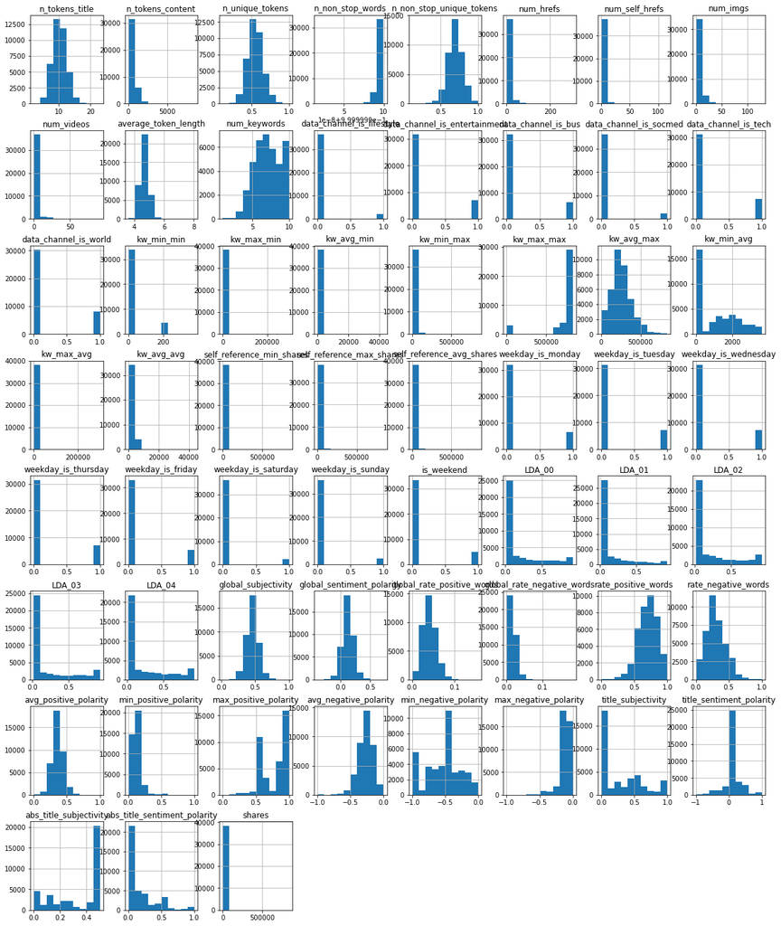

```python
plt.rcParams["figure.figsize"] = 20,25
fig = data[data.columns].hist()
```

Some histograms are less compressed while other remain the overall the same. This source of error might came from outliers in our dataset. We can easily check in some of the histograms above, for example *n_tokens_title*, that the x-axis is extended for invisible values on the y-axis. Before discussing the most appropriate reaction, let's examine the values that have [1 in 10^50](https://en.wikipedia.org/wiki/68%E2%80%9395%E2%80%9399.7_rule) chance to exceed the mean, that is to say, the $D$ values such as $|D-\mu_{feature}| > 15\cdot \sigma_{feature}$.

```python
potential_outliers = ['n_tokens_content', 'num_hrefs', 'num_self_hrefs', 'num_imgs', 'num_videos',
                      'kw_min_min', 'kw_max_min', 'kw_avg_min', 'kw_min_max', 'kw_max_max', 'kw_max_avg', 'kw_avg_avg',
                      'self_reference_min_shares', 'self_reference_max_shares', 'self_reference_avg_shares']

for column in potential_outliers :
    mean = data[column].mean()
    sigma = data[column].std()
    D = list()
    for d in data[column] :
        if abs(d - mean) > 15 * sigma :
            D.append(d)
    print(column, "mean =", round(mean, 2), "number of outliers =", len(D))
```

```
n_tokens_content mean = 563.32 number of outliers = 2
num_hrefs mean = 11.22 number of outliers = 3
num_self_hrefs mean = 3.39 number of outliers = 7
num_imgs mean = 4.56 number of outliers = 0
num_videos mean = 1.26 number of outliers = 18
kw_min_min mean = 26.71 number of outliers = 0
kw_max_min mean = 1151.81 number of outliers = 24
kw_avg_min mean = 313.96 number of outliers = 22
kw_min_max mean = 13180.99 number of outliers = 0
kw_max_max mean = 750311.28 number of outliers = 0
kw_max_avg mean = 5603.92 number of outliers = 33
kw_avg_avg mean = 3103.39 number of outliers = 10
self_reference_min_shares mean = 4121.88 number of outliers = 25
self_reference_max_shares mean = 10646.02 number of outliers = 109
self_reference_avg_shares mean = 6597.99 number of outliers = 34
```

The outlier criteria is intrinsically related to its standard deviation. Thus, we won't consider the features who are already in the $[-1, 1]$ interval but only those whose histograms are compressed to surprising extreme values. After that, we'll check that the number of outliers in *shares* hasn't significatively change, this would mean that the extreme values were not necessary.

```python
def outliers_indexes(column, degree) :
    mean = data[column].mean()
    sigma = data[column].std()
    indexes = list()
    for i in data.index :
        if abs(data[column][i] - mean) > degree * sigma :
            indexes.append(i)
    return indexes

data = data.drop(outliers_indexes('n_tokens_content', 15), axis = 0)
data = data.drop(outliers_indexes('num_hrefs', 15), axis = 0)
data = data.drop(outliers_indexes('num_self_hrefs', 15), axis = 0)
data = data.drop(outliers_indexes('num_imgs', 15), axis = 0)
data = data.drop(outliers_indexes('num_videos', 15), axis = 0)
data = data.drop(outliers_indexes('kw_min_min', 15), axis = 0)
data = data.drop(outliers_indexes('kw_max_min', 15), axis = 0)
data = data.drop(outliers_indexes('kw_avg_min', 15), axis = 0)
data = data.drop(outliers_indexes('kw_min_max', 15), axis = 0)
data = data.drop(outliers_indexes('kw_max_max', 15), axis = 0)
data = data.drop(outliers_indexes('kw_max_avg', 15), axis = 0)
data = data.drop(outliers_indexes('kw_avg_avg', 15), axis = 0)
data = data.drop(outliers_indexes('self_reference_min_shares', 15), axis = 0)
data = data.drop(outliers_indexes('self_reference_max_shares', 15), axis = 0)
data = data.drop(outliers_indexes('self_reference_avg_shares', 15), axis = 0)
```

Let's plot once more the histograms.

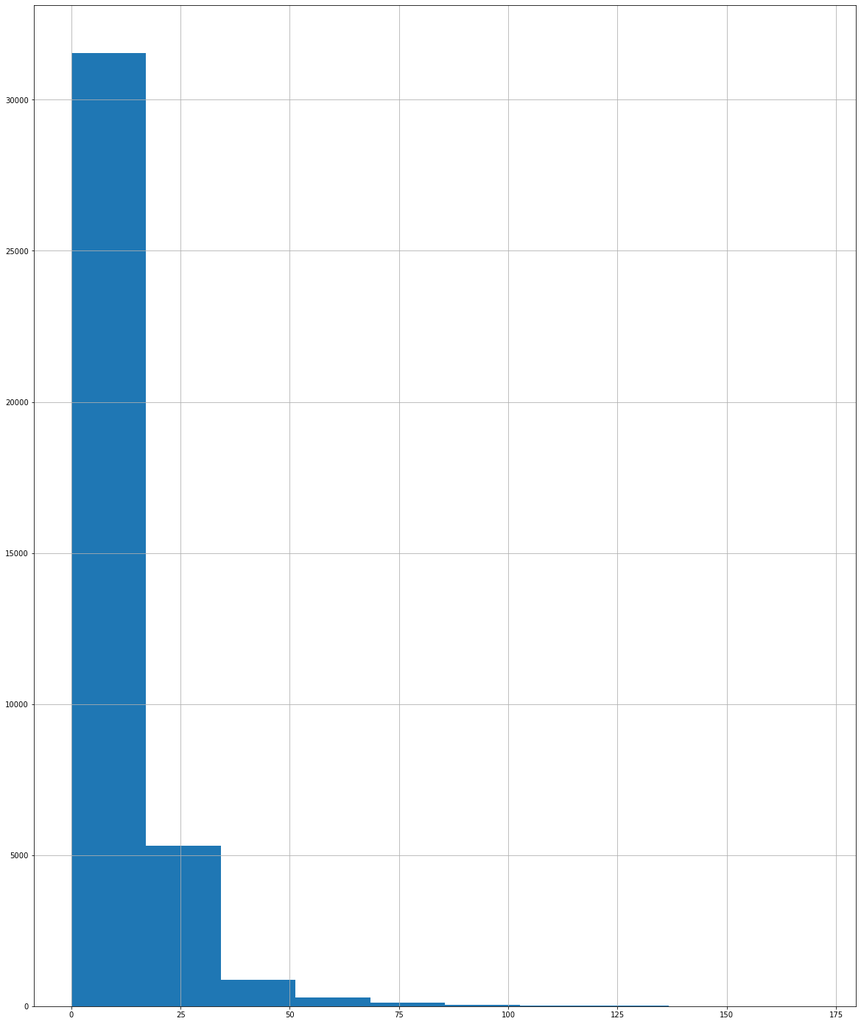

```python
plt.rcParams["figure.figsize"] = 20,25
fig = data['num_hrefs'].hist()
```

Undeniably, we have an easier time to estimate the different distributions, for example *num_hrefs* appears to be following an exponential distribution whereas in the precedent histogram it looked like one range of values dominated the rest outside that range. Let's check if we've significantly changed the explained variable after all these changes :

```python
data.shares.describe()
```

```
count     38237.000000
mean       3321.762534
std       11050.341900
min           1.000000
25%         944.000000
50%        1400.000000
75%        2700.000000
max      843300.000000
Name: shares, dtype: float64
```

```python
pd.read_csv("OnlineNewsPopularity.csv")[' shares'].describe()
```

```
count     39644.000000
mean       3395.380184
std       11626.950749
min           1.000000
25%         946.000000
50%        1400.000000
75%        2800.000000
max      843300.000000
Name:  shares, dtype: float64
```

We can see that the original dataset doesn't really differ to the transformed one. We've lost 3% of the dataset and 5% of standard deviation which was likely the result of noise as we've explained.

## Transforming the dataset

### Generic methods for visualization and transformation

We write the different methods that enable us to plot histograms, density plots, probability-probability plots as well as to transform data as we please.

```python
from scipy import stats
from scipy.stats import norm, skew
from sklearn.preprocessing import StandardScaler

# examine() plots a column's density plot as well as prints out the skewness and kurtosis of its curve
def examine(column) :
    sns.distplot(data[column])
    print('Skewness of the curve :', data[column].skew())
    print('Kurtosis of the curve :', data[column].kurt())

# transform() plots the before and after transformation of a column according to a specified model.
# The different models correspond to the inverse of the law the column is supposed to follow so as to normalize it.
# "Normal" standardizes the column, "Log" return the logarithm of the column, "Log+1" and "Log+2" also but prevent log(0) values.
# (a, b) returns the inverse of the Beta distribution whose parameters are alpha = a and beta = b.
def transform(column, method = "Normal") :
    fig = plt.figure(figsize = (15, 5))
    plt.subplot(1,2,1)
    sns.distplot(data[column], fit = norm);
    (mu, sigma) = norm.fit(data[column])
    plt.legend(['Normal dist. ($\mu=$ {:.2f} and $\sigma=$ {:.2f} )'.format(mu, sigma)], loc = 1)
    plt.ylabel('Frequency')
    plt.title(str(column) + ' distribution')
    plt.subplot(1,2,2)
    res = stats.probplot(data[column], plot = plt)
    plt.suptitle('Before transformation')

    if method == "Normal" :
        data[column] = (data[column] - data[column].mean()) / data[column].std()
    elif method == "Log" :
        data[column] = np.log(data[column])
    elif method == "Log+1" :
        data[column] = np.log1p(data[column])
    elif method == "Log+2" :
        data[column] = np.log(data[column] + 2)
    else :
        data[column] = stats.beta.pdf(data[column], a = method[0], b = method[1])
        data[column] = data[column] / data[column].max()

    fig = plt.figure(figsize = (15, 5))
    plt.subplot(1,2,1)
    sns.distplot(data[column], fit = norm);
    (mu, sigma) = norm.fit(data[column])
    plt.legend(['Normal dist. ($\mu=$ {:.2f} and $\sigma=$ {:.2f} )'.format(mu, sigma)], loc=1)
    plt.ylabel('Frequency')
    plt.title(str(column) + ' distribution')
    plt.subplot(1,2,2)
    res = stats.probplot(data[column], plot = plt)
    plt.suptitle('After ' + str(method) + ' transformation')

# hist() returns the histogram of one or more columns
def hist(columns) :
    plt.rcParams["figure.figsize"] = (20, 20)
    fig = data[columns].hist()

# corrplot() returns the corrplots of two or more columns based on the Pearson's or Spearman's correlation coefficient.
def corrplot(columns, method = 'pearson') :
    sns.heatmap(data[columns].corr(method),
                vmin = -1, vmax = 1, cmap = 'coolwarm',
                annot = True, square = True);
```

### Examining the target *shares*

Let's examine the dependent variable *shares*.

```python
data['shares'].describe()
```

```
count     38237.000000
mean       3321.762534
std       11050.341900
min           1.000000
25%         944.000000
50%        1400.000000
75%        2700.000000
max      843300.000000
Name: shares, dtype: float64
```

### Transforming the feature *n_tokens_title*

Let's examine the feature *n_tokens_title*.

```
Skewness of the curve : 0.17126497907685115
Kurtosis of the curve : 0.004984333656849138
```

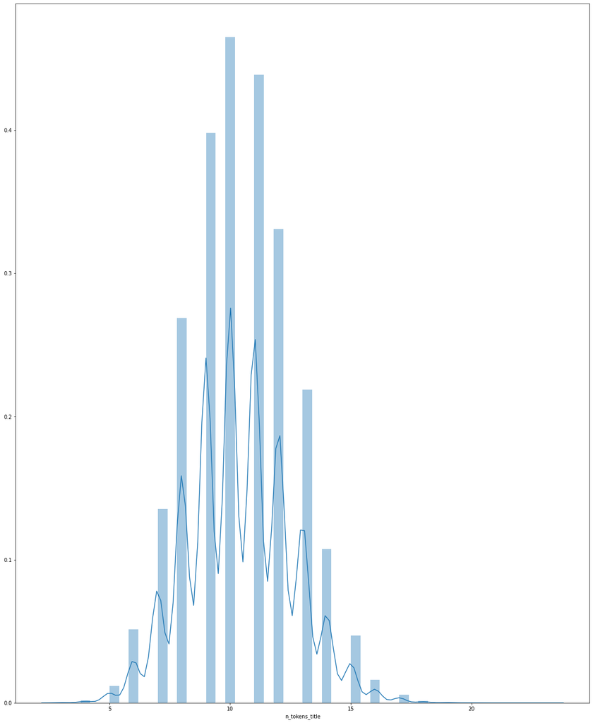

```python
examine('n_tokens_title')
```

It seems fair to assume the probability distribution of *n_tokens_title* follows a normal law. Let's standardize it to follow $\mathcal{N}(0, 1)$ law in order to restrain it as much as possible to the $[-1, 1]$ interval.

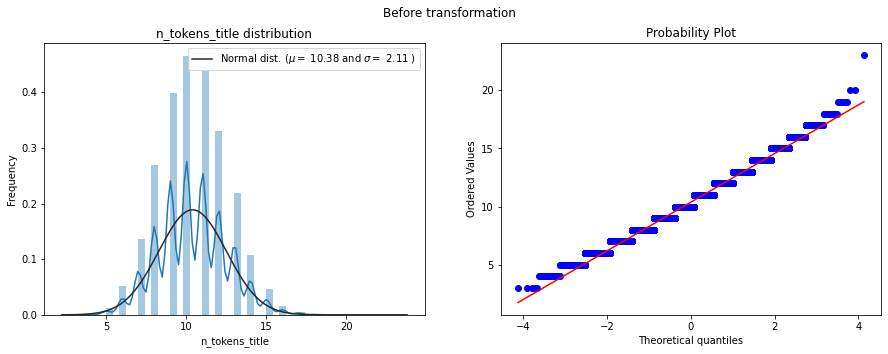

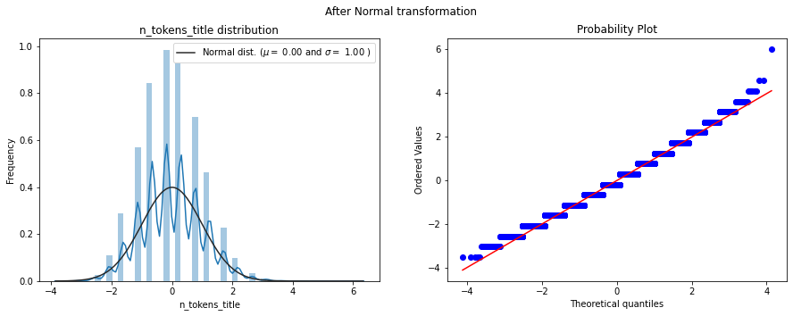

```python
transform('n_tokens_title')
```

### Transforming the feature *n_tokens_content*

Let's examine the feature *n_tokens_content*.

```
Skewness of the curve : 2.8823139451689705
Kurtosis of the curve : 17.42465691058095
```

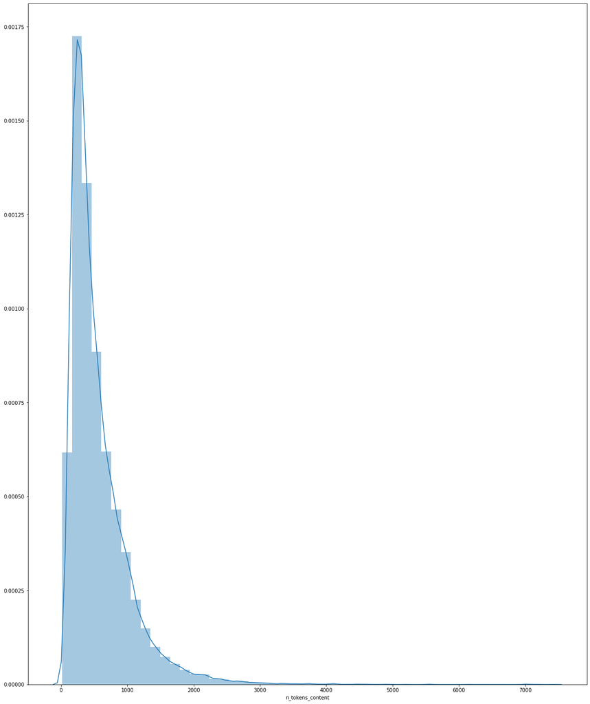

```python
examine('n_tokens_content')
```

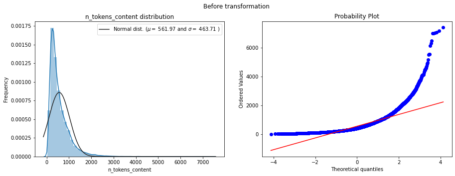

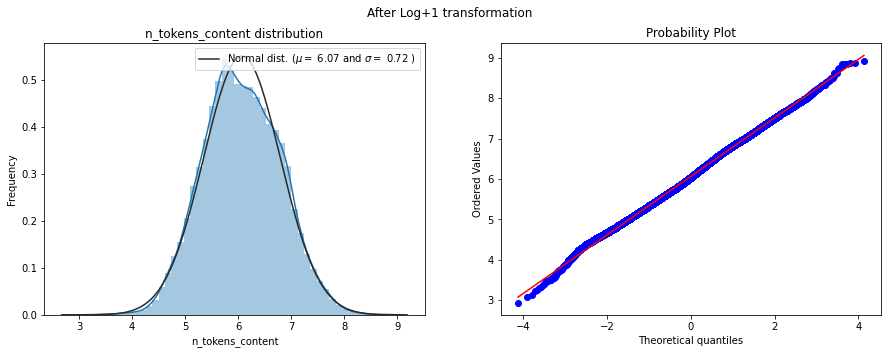

```python
transform('n_tokens_content', "Log+1")
```

### Transforming the feature *n_non_stop_words*

Let's examine the feature *n_non_stop_words*.

```
Skewness of the curve : 0.0
Kurtosis of the curve : 0
```

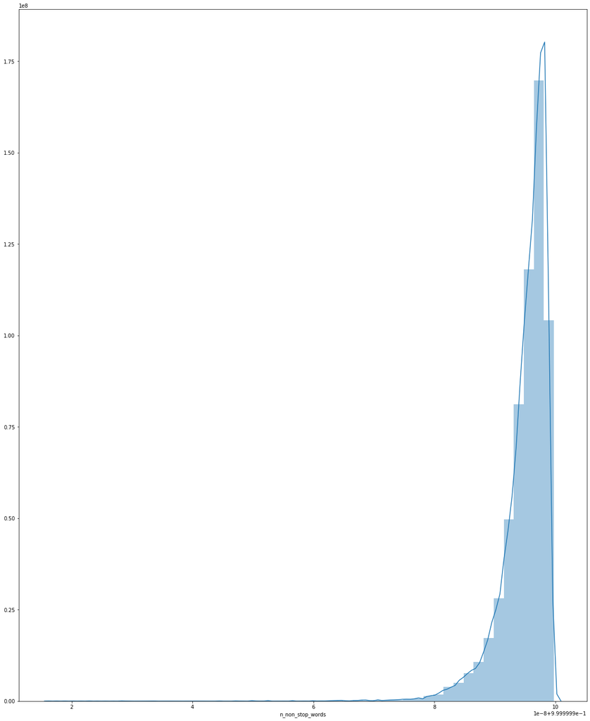

```python
examine('n_non_stop_words')
```

The feature *n_non_stop_words* follows what appears to be an inverse exponential law. The results when normalizing through **np.log1m** and **$\frac{X-\mu}{\sigma}$** were unsatisfying. We came to the conclusion that the distribution follows the Beta $\beta(\alpha,\beta)$ distribution whose parameters we shall estimate via la méthode des moments. Indeed, if $X\hookrightarrow\beta(\alpha,\beta)$, then $E(X)=\frac{\alpha}{\alpha+\beta}$ and $V(X)=\frac{\alpha\cdot\beta}{(\alpha+\beta)^2\cdot(\alpha+\beta+1)}$. If we estimate $E(X)$ and $V(X)$ by applying respectively **mean()** and **std()** to *n_non_stop_words*, then we have $\alpha = k\cdot\beta$ and $\beta^2 + \frac{1}{k+1}\beta - \frac{k}{(k+1)^3\cdot V(X)}=0$ where $k=\frac{E(X)}{1-E(X)}$. Let's first determine the parameters.

```python
mean = data['n_non_stop_words'].mean()
var = data['n_non_stop_words'].std() ** 2

k = mean / (1 - mean)
delta = (1/(k+1))**2 - 4 * 1 * (- k / ((k+1)**3 * var)) # delta > 0
b1 = (-1/(k+1) + np.sqrt(delta)) / (2 * 1) # b1 > 0, possible solution
b2 = (-1/(k+1) - np.sqrt(delta)) / (2 * 1) # b2 < 0, impossible solution

beta = b1
alpha = k * beta
(alpha, beta)
```

```
(248921561.7222095, 1.2364573608989249)
```

When plotted on a [casio](https://keisan.casio.com/exec/system/1180573226) the distribution fits. Let's now apply the beta density function **beta.pdf()** and the **max** scaling $x_{scale} = \frac{x}{max(x)}$.

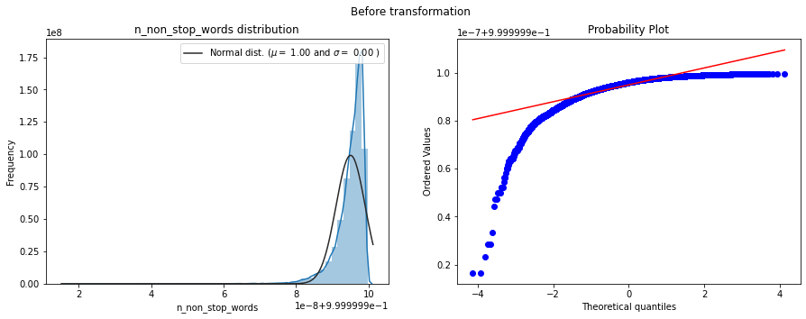

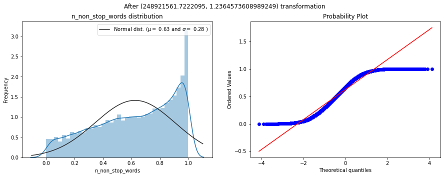

```python
transform('n_non_stop_words', (alpha, beta))
```

The probability has been scaled in a shape that we hope neither affects the model (overfitting/underfitting) nor the feature.

### Transforming the feature *num_hrefs*

Let's examine the feature *num_hrefs*.

```
Skewness of the curve : 3.552859244529797
Kurtosis of the curve : 22.79810554369345
```

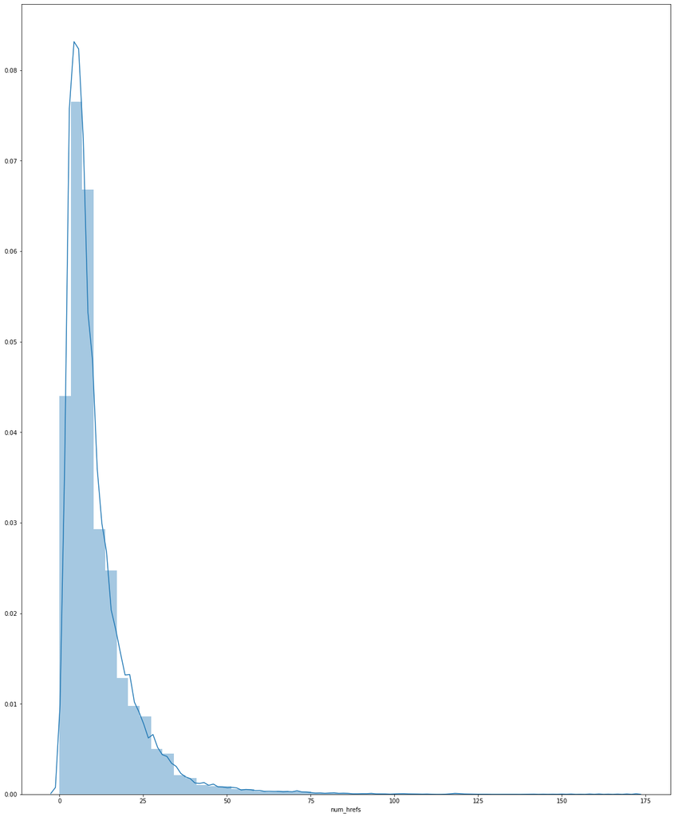

```python
examine('num_hrefs')
```

The feature *num_hrefs* follows what appears to be an exponential law.

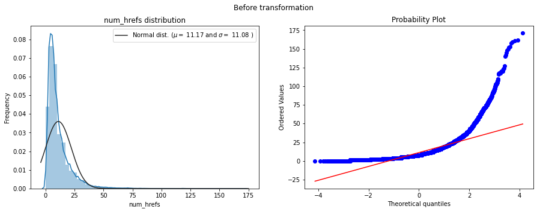

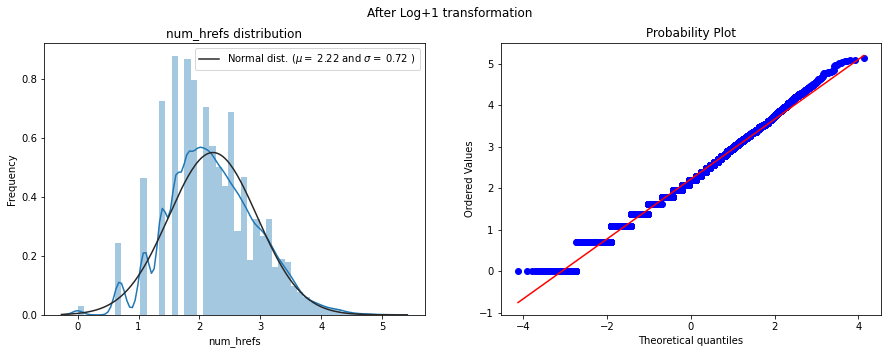

```python
transform('num_hrefs', "Log+1")
```

### Transforming the feature *num_self_hrefs*

Let's examine the feature *num_self_hrefs*.

```
Skewness of the curve : 4.293580035707188
Kurtosis of the curve : 31.305402894223857
```

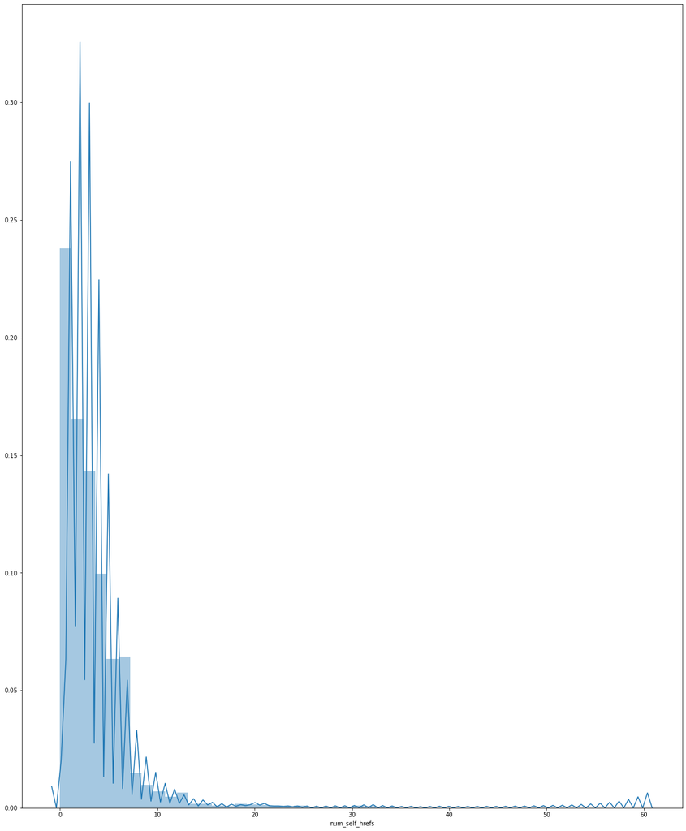

```python
examine('num_self_hrefs')
```

The feature *num_self_hrefs* follows what appears to be an exponential law.

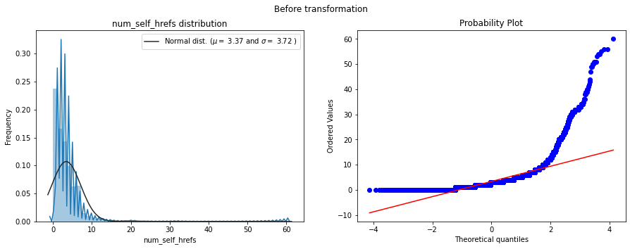

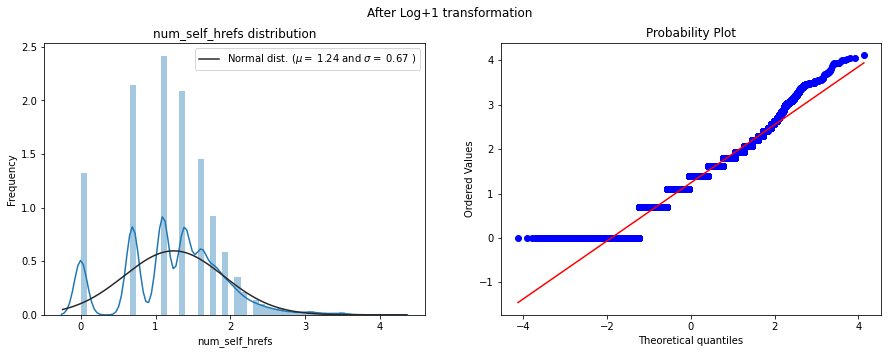

```python
transform('num_self_hrefs', "Log+1")
```

### Transforming the feature *num_imgs*

Let's examine the feature *num_imgs*.

```
Skewness of the curve : 3.927585463570177
Kurtosis of the curve : 24.15257395372454
```

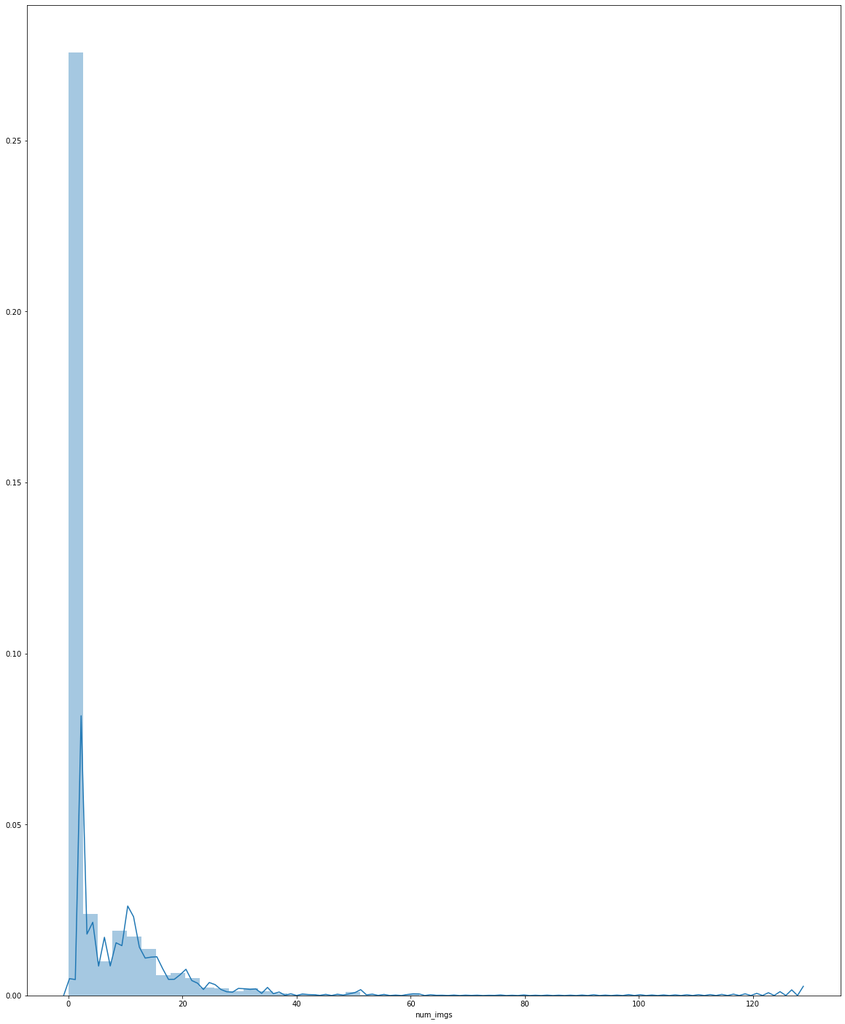

```python
examine('num_imgs')
```

The feature *num_imgs* follows what appears to be an exponential law.

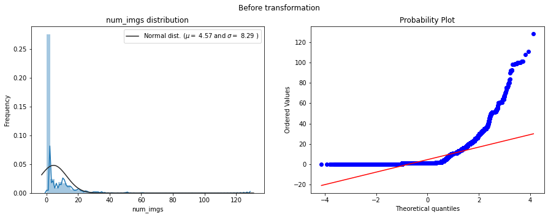

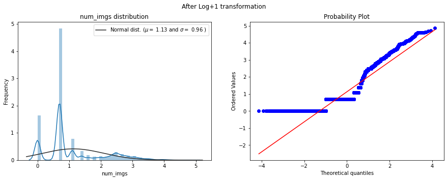

```python
transform('num_imgs', "Log+1")
```

### Transforming the feature *num_videos*

Let's examine the feature *num_videos*.

```
Skewness of the curve : 5.619257124963665
Kurtosis of the curve : 39.98696431708395
```

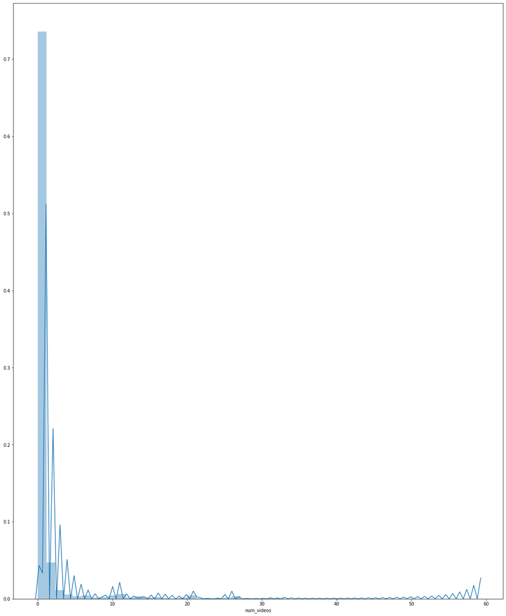

```python
examine('num_videos')
```

The feature *num_videos* follows what appears to be an exponential law.

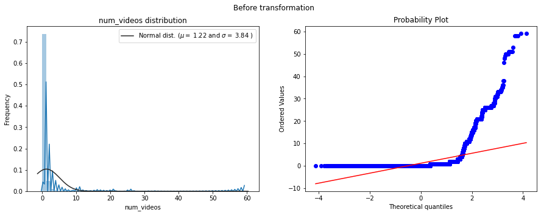

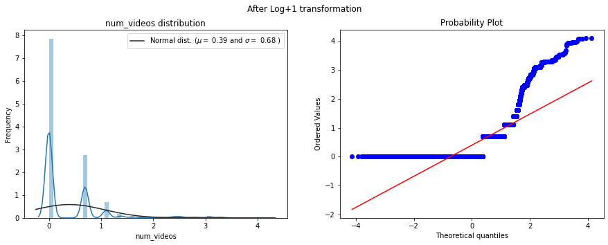

```python
transform('num_videos', "Log+1")
```

### Transforming the features *rate_positive_words* and *rate_negative_words*

Let's examine the pair of features *rate_positive_words* and *rate_negative_words*.

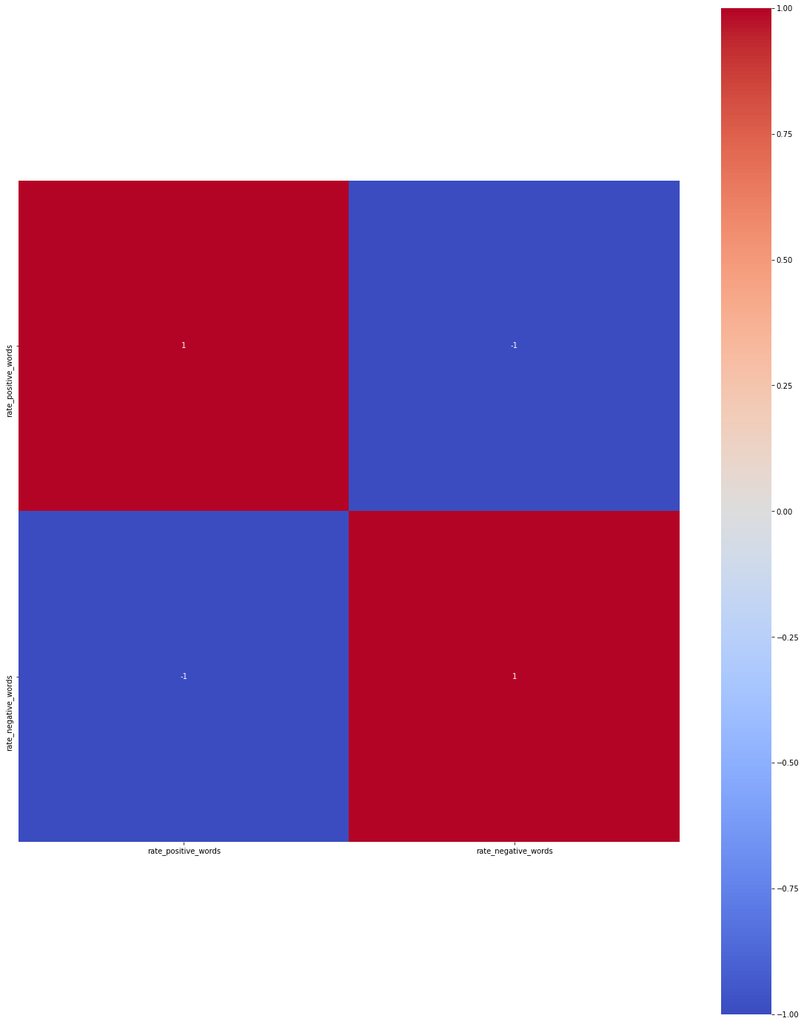

```python
corrplot(['rate_positive_words', 'rate_negative_words'])
```

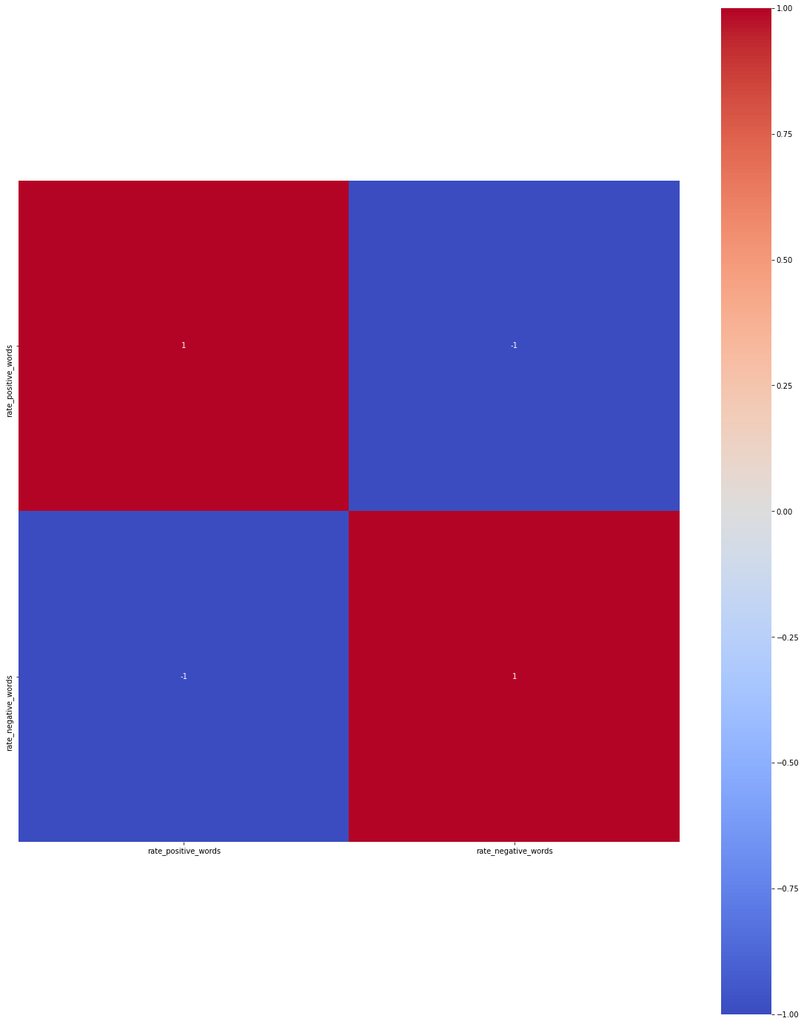

```python
corrplot(['rate_positive_words', 'rate_negative_words'], 'spearman')
```

Through both Pearson's and Spearman's correlation coefficient methods, the linear dependancy between *rate_positive_words* and *rate_negative_words* is undeniable. To prevent the model to overfit by adjusting the weight he gives to both features, we shall remove the latter one. Indeed, if we know the value of the first feature we know exactly the value of the other one, the explained variance from both features is the same.

```python
data = data.drop('rate_negative_words', 1)
```

### Transforming the features *keywords*

Let's examine the features *kw_avg_avg*, *kw_avg_max*, *kw_avg_min*, *kw_max_avg*, *kw_max_max*, *kw_max_min*, *kw_min_avg*, *kw_min_max* and *kw_min_min*.

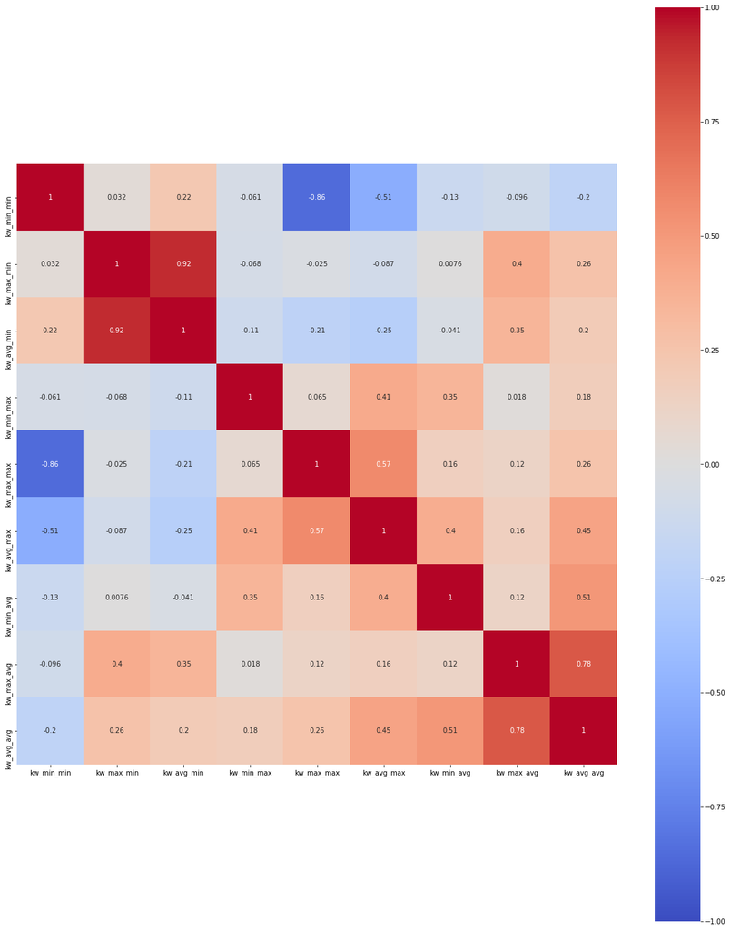

```python
corrplot(['kw_min_min', 'kw_max_min', 'kw_avg_min', 'kw_min_max',
          'kw_max_max', 'kw_avg_max', 'kw_min_avg', 'kw_max_avg', 'kw_avg_avg'])
```

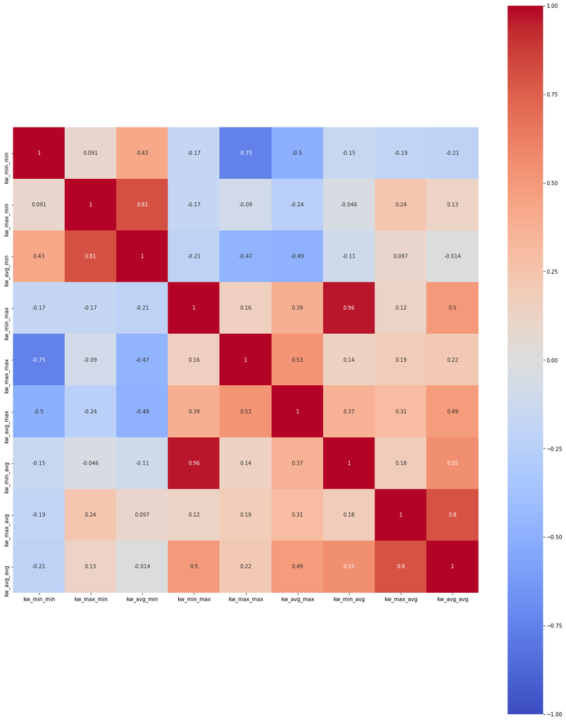

```python
corrplot(['kw_min_min', 'kw_max_min', 'kw_avg_min', 'kw_min_max',
          'kw_max_max', 'kw_avg_max', 'kw_min_avg', 'kw_max_avg', 'kw_avg_avg'], 'spearman')
```

For the same reasons as before, we'll remove the *kw*avg*...* features, as they are intrinsically defined by *kw*min*...* and *kw*max*...*. Moreover, the average is likely estimated from the arithmetic mean $m = \frac{a+b}{2}$. On the contrary to the geometric mean $m = \sqrt{a\cdot b}$, the arithmetic mean is heavily penalized by extreme values, thus the weights of *kw*min*...* and *kw*max*...* on the average is significant, as showcased by the linear correlation plots above.

```python
data = data.drop(['kw_avg_min', 'kw_avg_max', 'kw_avg_avg'], 1)
```

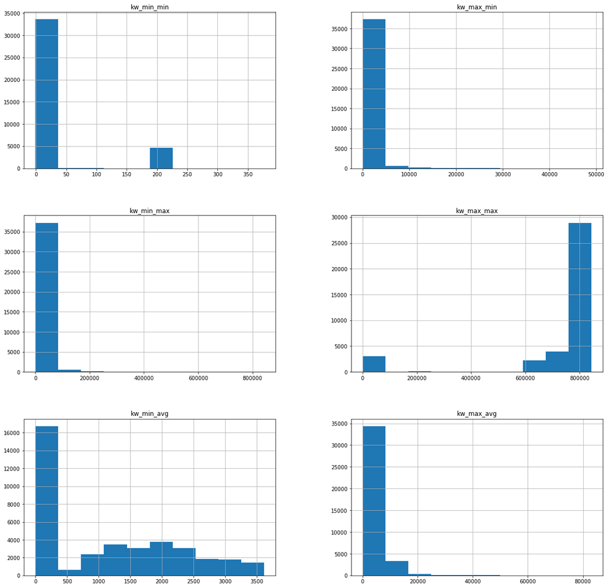

```python
hist(['kw_min_min', 'kw_max_min', 'kw_min_max', 'kw_max_max', 'kw_min_avg', 'kw_max_avg'])
```

Let us apply **np.log** to all features.

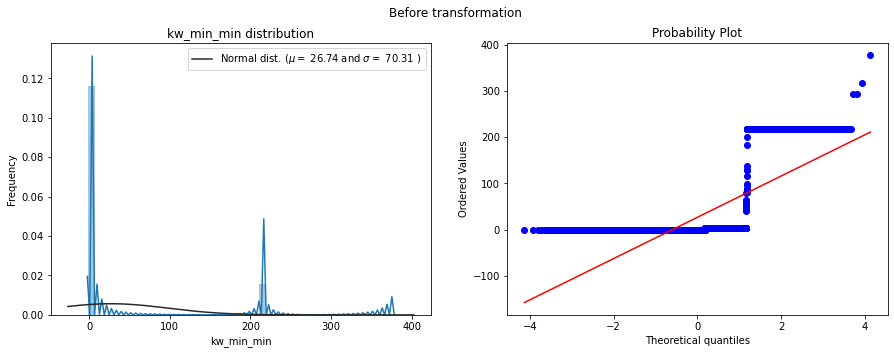

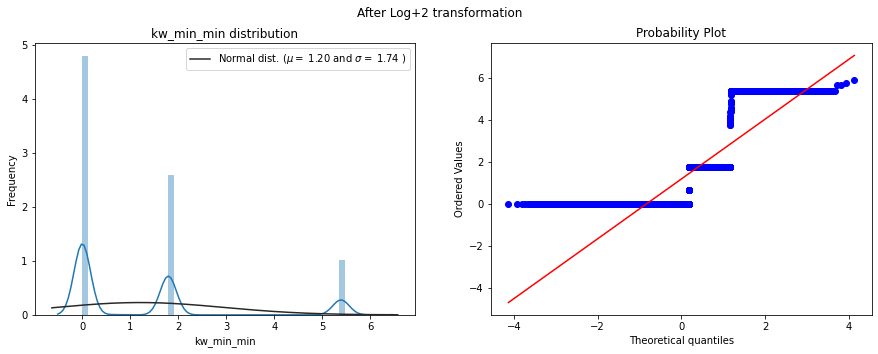

```python
transform('kw_min_min', 'Log+2')
```